# Risk Factor Analysis

## Outcome Variable

**Outcome Variable:** swasted

## Predictor Variables

**Intervention Variable:** meducyrs

**Adjustment Set:**

- arm
- W_mage
- feducyrs
- hhwealth_quart
- W_mhtcm
- W_gagebrth
- W_birthwt
- W_birthlen
- W_nrooms
- impfloor
- impsan
- safeh20
- delta_W_mage
- delta_feducyrs
- delta_hhwealth_quart
- delta_W_mhtcm
- delta_W_gagebrth
- delta_W_birthwt
- delta_W_birthlen
- delta_W_nrooms
- delta_impfloor
- delta_impsan
- delta_safeh20

## Stratifying Variables

The analysis was stratified on these variable(s):

- agecat
- studyid
- country

## Data Summary

| agecat | studyid | country | meducyrs | swasted | n_cell | n |
| --- | --- | --- | --- | --- | --- | --- |
| Birth | ki0047075b-MAL-ED | BANGLADESH | Low | 0 | 61 | 195 |
| Birth | ki0047075b-MAL-ED | BANGLADESH | Low | 1 | 2 | 195 |
| Birth | ki0047075b-MAL-ED | BANGLADESH | Medium | 0 | 57 | 195 |
| Birth | ki0047075b-MAL-ED | BANGLADESH | Medium | 1 | 3 | 195 |
| Birth | ki0047075b-MAL-ED | BANGLADESH | High | 0 | 71 | 195 |
| Birth | ki0047075b-MAL-ED | BANGLADESH | High | 1 | 1 | 195 |
| Birth | ki0047075b-MAL-ED | BRAZIL | Low | 0 | 51 | 182 |
| Birth | ki0047075b-MAL-ED | BRAZIL | Low | 1 | 0 | 182 |
| Birth | ki0047075b-MAL-ED | BRAZIL | Medium | 0 | 68 | 182 |
| Birth | ki0047075b-MAL-ED | BRAZIL | Medium | 1 | 0 | 182 |
| Birth | ki0047075b-MAL-ED | BRAZIL | High | 0 | 63 | 182 |
| Birth | ki0047075b-MAL-ED | BRAZIL | High | 1 | 0 | 182 |
| Birth | ki0047075b-MAL-ED | INDIA | Low | 0 | 59 | 180 |
| Birth | ki0047075b-MAL-ED | INDIA | Low | 1 | 1 | 180 |
| Birth | ki0047075b-MAL-ED | INDIA | Medium | 0 | 64 | 180 |
| Birth | ki0047075b-MAL-ED | INDIA | Medium | 1 | 5 | 180 |
| Birth | ki0047075b-MAL-ED | INDIA | High | 0 | 50 | 180 |
| Birth | ki0047075b-MAL-ED | INDIA | High | 1 | 1 | 180 |
| Birth | ki0047075b-MAL-ED | NEPAL | Low | 0 | 65 | 155 |
| Birth | ki0047075b-MAL-ED | NEPAL | Low | 1 | 0 | 155 |
| Birth | ki0047075b-MAL-ED | NEPAL | Medium | 0 | 51 | 155 |
| Birth | ki0047075b-MAL-ED | NEPAL | Medium | 1 | 2 | 155 |
| Birth | ki0047075b-MAL-ED | NEPAL | High | 0 | 36 | 155 |
| Birth | ki0047075b-MAL-ED | NEPAL | High | 1 | 1 | 155 |
| Birth | ki0047075b-MAL-ED | PERU | Low | 0 | 98 | 278 |
| Birth | ki0047075b-MAL-ED | PERU | Low | 1 | 0 | 278 |
| Birth | ki0047075b-MAL-ED | PERU | Medium | 0 | 98 | 278 |
| Birth | ki0047075b-MAL-ED | PERU | Medium | 1 | 0 | 278 |
| Birth | ki0047075b-MAL-ED | PERU | High | 0 | 82 | 278 |
| Birth | ki0047075b-MAL-ED | PERU | High | 1 | 0 | 278 |

[output cut: 378 more lines]

The following strata were considered:

- agecat: 24 months, studyid: ki0047075b-MAL-ED, country: BANGLADESH
- agecat: 24 months, studyid: ki0047075b-MAL-ED, country: BRAZIL
- agecat: 24 months, studyid: ki0047075b-MAL-ED, country: INDIA
- agecat: 24 months, studyid: ki0047075b-MAL-ED, country: NEPAL
- agecat: 24 months, studyid: ki0047075b-MAL-ED, country: PERU
- agecat: 24 months, studyid: ki0047075b-MAL-ED, country: SOUTH AFRICA
- agecat: 24 months, studyid: ki0047075b-MAL-ED, country: TANZANIA, UNITED REPUBLIC OF
- agecat: 24 months, studyid: ki1000108-CMC-V-BCS-2002, country: INDIA
- agecat: 24 months, studyid: ki1000108-IRC, country: INDIA
- agecat: 24 months, studyid: ki1017093-NIH-Birth, country: BANGLADESH
- agecat: 24 months, studyid: ki1017093b-PROVIDE, country: BANGLADESH
- agecat: 24 months, studyid: ki1017093c-NIH-Crypto, country: BANGLADESH
- agecat: 24 months, studyid: ki1066203-TanzaniaChild2, country: TANZANIA, UNITED REPUBLIC OF
- agecat: 24 months, studyid: ki1113344-GMS-Nepal, country: NEPAL
- agecat: 24 months, studyid: ki1119695-PROBIT, country: BELARUS
- agecat: 24 months, studyid: ki1126311-ZVITAMBO, country: ZIMBABWE
- agecat: 24 months, studyid: ki1135781-COHORTS, country: GUATEMALA
- agecat: 24 months, studyid: ki1135781-COHORTS, country: INDIA
- agecat: 24 months, studyid: ki1135781-COHORTS, country: PHILIPPINES
- agecat: 24 months, studyid: ki1148112-LCNI-5, country: MALAWI
- agecat: 24 months, studyid: kiGH5241-JiVitA-3, country: BANGLADESH
- agecat: 24 months, studyid: kiGH5241-JiVitA-4, country: BANGLADESH
- agecat: 6 months, studyid: ki0047075b-MAL-ED, country: BANGLADESH
- agecat: 6 months, studyid: ki0047075b-MAL-ED, country: BRAZIL
- agecat: 6 months, studyid: ki0047075b-MAL-ED, country: INDIA
- agecat: 6 months, studyid: ki0047075b-MAL-ED, country: NEPAL
- agecat: 6 months, studyid: ki0047075b-MAL-ED, country: PERU
- agecat: 6 months, studyid: ki0047075b-MAL-ED, country: SOUTH AFRICA
- agecat: 6 months, studyid: ki0047075b-MAL-ED, country: TANZANIA, UNITED REPUBLIC OF
- agecat: 6 months, studyid: ki1000108-CMC-V-BCS-2002, country: INDIA
- agecat: 6 months, studyid: ki1000108-IRC, country: INDIA
- agecat: 6 months, studyid: ki1000109-EE, country: PAKISTAN
- agecat: 6 months, studyid: ki1000304b-SAS-CompFeed, country: INDIA
- agecat: 6 months, studyid: ki1000304b-SAS-FoodSuppl, country: INDIA
- agecat: 6 months, studyid: ki1017093-NIH-Birth, country: BANGLADESH
- agecat: 6 months, studyid: ki1017093b-PROVIDE, country: BANGLADESH
- agecat: 6 months, studyid: ki1017093c-NIH-Crypto, country: BANGLADESH
- agecat: 6 months, studyid: ki1066203-TanzaniaChild2, country: TANZANIA, UNITED REPUBLIC OF
- agecat: 6 months, studyid: ki1112895-Guatemala BSC, country: GUATEMALA
- agecat: 6 months, studyid: ki1113344-GMS-Nepal, country: NEPAL
- agecat: 6 months, studyid: ki1119695-PROBIT, country: BELARUS
- agecat: 6 months, studyid: ki1126311-ZVITAMBO, country: ZIMBABWE
- agecat: 6 months, studyid: ki1135781-COHORTS, country: GUATEMALA
- agecat: 6 months, studyid: ki1135781-COHORTS, country: INDIA
- agecat: 6 months, studyid: ki1135781-COHORTS, country: PHILIPPINES
- agecat: 6 months, studyid: ki1148112-LCNI-5, country: MALAWI
- agecat: 6 months, studyid: kiGH5241-JiVitA-3, country: BANGLADESH
- agecat: 6 months, studyid: kiGH5241-JiVitA-4, country: BANGLADESH
- agecat: Birth, studyid: ki0047075b-MAL-ED, country: BANGLADESH
- agecat: Birth, studyid: ki0047075b-MAL-ED, country: BRAZIL
- agecat: Birth, studyid: ki0047075b-MAL-ED, country: INDIA
- agecat: Birth, studyid: ki0047075b-MAL-ED, country: NEPAL
- agecat: Birth, studyid: ki0047075b-MAL-ED, country: PERU
- agecat: Birth, studyid: ki0047075b-MAL-ED, country: SOUTH AFRICA
- agecat: Birth, studyid: ki0047075b-MAL-ED, country: TANZANIA, UNITED REPUBLIC OF
- agecat: Birth, studyid: ki1000108-CMC-V-BCS-2002, country: INDIA
- agecat: Birth, studyid: ki1000108-IRC, country: INDIA
- agecat: Birth, studyid: ki1000109-EE, country: PAKISTAN
- agecat: Birth, studyid: ki1000304b-SAS-CompFeed, country: INDIA
- agecat: Birth, studyid: ki1017093-NIH-Birth, country: BANGLADESH
- agecat: Birth, studyid: ki1017093c-NIH-Crypto, country: BANGLADESH
- agecat: Birth, studyid: ki1119695-PROBIT, country: BELARUS
- agecat: Birth, studyid: ki1126311-ZVITAMBO, country: ZIMBABWE
- agecat: Birth, studyid: ki1135781-COHORTS, country: GUATEMALA
- agecat: Birth, studyid: ki1135781-COHORTS, country: INDIA
- agecat: Birth, studyid: ki1135781-COHORTS, country: PHILIPPINES
- agecat: Birth, studyid: kiGH5241-JiVitA-3, country: BANGLADESH
- agecat: Birth, studyid: kiGH5241-JiVitA-4, country: BANGLADESH

### Dropped Strata

Some strata were dropped due to rare outcomes:

- agecat: Birth, studyid: ki0047075b-MAL-ED, country: BANGLADESH
- agecat: Birth, studyid: ki0047075b-MAL-ED, country: BRAZIL
- agecat: Birth, studyid: ki0047075b-MAL-ED, country: INDIA
- agecat: Birth, studyid: ki0047075b-MAL-ED, country: NEPAL
- agecat: Birth, studyid: ki0047075b-MAL-ED, country: PERU
- agecat: Birth, studyid: ki0047075b-MAL-ED, country: SOUTH AFRICA
- agecat: Birth, studyid: ki0047075b-MAL-ED, country: TANZANIA, UNITED REPUBLIC OF
- agecat: Birth, studyid: ki1000108-CMC-V-BCS-2002, country: INDIA
- agecat: Birth, studyid: ki1000109-EE, country: PAKISTAN
- agecat: Birth, studyid: ki1000304b-SAS-CompFeed, country: INDIA
- agecat: Birth, studyid: ki1017093-NIH-Birth, country: BANGLADESH
- agecat: Birth, studyid: ki1017093c-NIH-Crypto, country: BANGLADESH
- agecat: Birth, studyid: kiGH5241-JiVitA-4, country: BANGLADESH
- agecat: 6 months, studyid: ki0047075b-MAL-ED, country: BANGLADESH
- agecat: 6 months, studyid: ki0047075b-MAL-ED, country: BRAZIL
- agecat: 6 months, studyid: ki0047075b-MAL-ED, country: INDIA
- agecat: 6 months, studyid: ki0047075b-MAL-ED, country: NEPAL
- agecat: 6 months, studyid: ki0047075b-MAL-ED, country: PERU
- agecat: 6 months, studyid: ki0047075b-MAL-ED, country: SOUTH AFRICA
- agecat: 6 months, studyid: ki0047075b-MAL-ED, country: TANZANIA, UNITED REPUBLIC OF
- agecat: 6 months, studyid: ki1000108-CMC-V-BCS-2002, country: INDIA
- agecat: 6 months, studyid: ki1000109-EE, country: PAKISTAN
- agecat: 6 months, studyid: ki1000304b-SAS-CompFeed, country: INDIA
- agecat: 6 months, studyid: ki1000304b-SAS-FoodSuppl, country: INDIA
- agecat: 6 months, studyid: ki1017093-NIH-Birth, country: BANGLADESH
- agecat: 6 months, studyid: ki1017093b-PROVIDE, country: BANGLADESH
- agecat: 6 months, studyid: ki1017093c-NIH-Crypto, country: BANGLADESH
- agecat: 6 months, studyid: ki1066203-TanzaniaChild2, country: TANZANIA, UNITED REPUBLIC OF
- agecat: 6 months, studyid: ki1112895-Guatemala BSC, country: GUATEMALA
- agecat: 6 months, studyid: ki1113344-GMS-Nepal, country: NEPAL
- agecat: 6 months, studyid: ki1119695-PROBIT, country: BELARUS
- agecat: 6 months, studyid: ki1135781-COHORTS, country: GUATEMALA
- agecat: 6 months, studyid: ki1148112-LCNI-5, country: MALAWI
- agecat: 6 months, studyid: kiGH5241-JiVitA-4, country: BANGLADESH
- agecat: 24 months, studyid: ki0047075b-MAL-ED, country: BANGLADESH
- agecat: 24 months, studyid: ki0047075b-MAL-ED, country: BRAZIL
- agecat: 24 months, studyid: ki0047075b-MAL-ED, country: INDIA
- agecat: 24 months, studyid: ki0047075b-MAL-ED, country: NEPAL
- agecat: 24 months, studyid: ki0047075b-MAL-ED, country: PERU
- agecat: 24 months, studyid: ki0047075b-MAL-ED, country: SOUTH AFRICA
- agecat: 24 months, studyid: ki0047075b-MAL-ED, country: TANZANIA, UNITED REPUBLIC OF
- agecat: 24 months, studyid: ki1000108-CMC-V-BCS-2002, country: INDIA
- agecat: 24 months, studyid: ki1000108-IRC, country: INDIA
- agecat: 24 months, studyid: ki1017093-NIH-Birth, country: BANGLADESH
- agecat: 24 months, studyid: ki1017093b-PROVIDE, country: BANGLADESH
- agecat: 24 months, studyid: ki1017093c-NIH-Crypto, country: BANGLADESH
- agecat: 24 months, studyid: ki1066203-TanzaniaChild2, country: TANZANIA, UNITED REPUBLIC OF
- agecat: 24 months, studyid: ki1113344-GMS-Nepal, country: NEPAL
- agecat: 24 months, studyid: ki1119695-PROBIT, country: BELARUS
- agecat: 24 months, studyid: ki1135781-COHORTS, country: GUATEMALA
- agecat: 24 months, studyid: ki1135781-COHORTS, country: INDIA
- agecat: 24 months, studyid: ki1148112-LCNI-5, country: MALAWI
- agecat: 24 months, studyid: kiGH5241-JiVitA-4, country: BANGLADESH

## Methods Detail

We’re interested in the causal parameters $E[Y_a]$ for all values of $a \in \mathcal{A}$. These parameters represent the mean outcome if, possibly contrary to fact, we intervened to set all units to have $A=a$. Under the randomization and positivity assumptions, these are identified by the statistical parameters $\psi_a=E_W[E_{Y|A,W}(Y|A=a,W)]$. In addition, we’re interested in the mean of $Y$, $E[Y]$ under no intervention (the observed mean). We will estimate these parameters by using SuperLearner to fit the relevant likelihood factors – $E_{Y|A,W}(Y|A=a,W)$ and $p(A=a|W)$, and then updating our likelihood fit using a joint TMLE.

For unadjusted analyses ($W=\{\}$), initial likelihoods were estimated using Lrnr_glm to estimate the simple $E(Y|A)$ and Lrnr_mean to estimate $p(A)$. For adjusted analyses, a small library containing Lrnr_glmnet, Lrnr_xgboost, and Lrnr_mean was used.

Having estimated these parameters, we will then use the delta method to estimate relative risks and attributable risks relative to a prespecified baseline level of $A$.

# Results Detail

## Results Plots

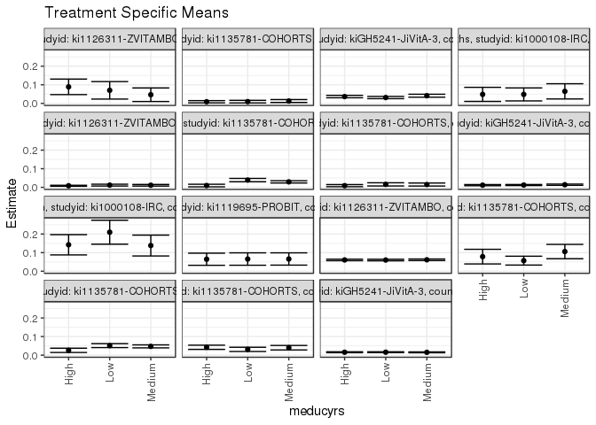

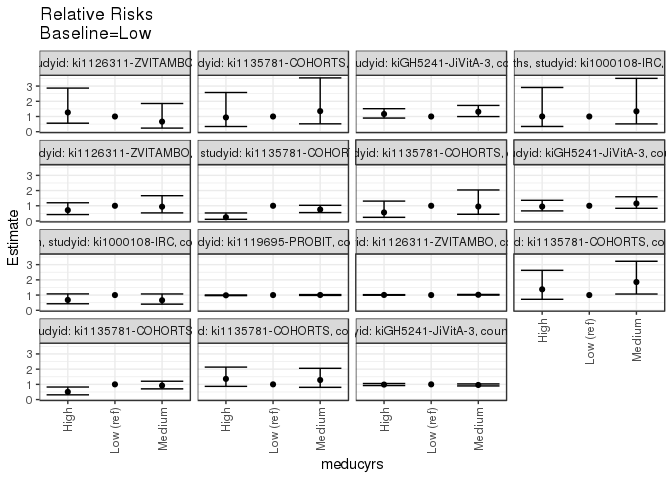

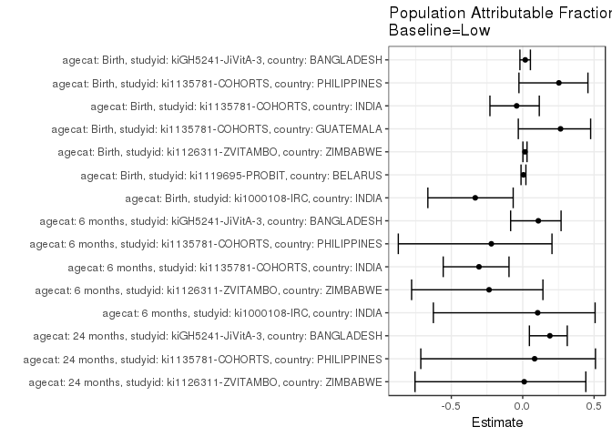

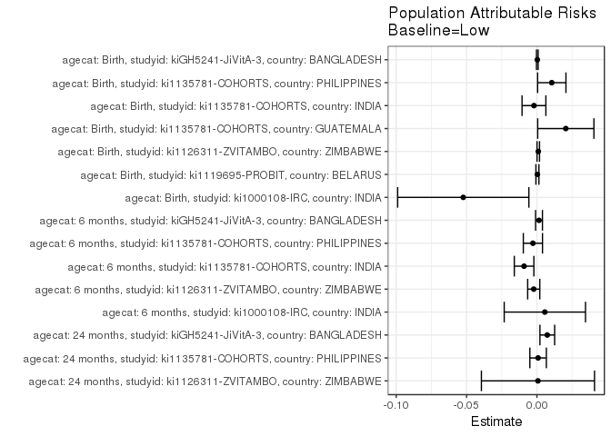

## Results Table

### Parameter: TSM

| agecat | studyid | country | intervention_level | baseline_level | estimate | ci_lower | ci_upper |
| --- | --- | --- | --- | --- | --- | --- | --- |
| Birth | ki1000108-IRC | INDIA | Low | NA | 0.2097823 | 0.1453370 | 0.2742277 |
| Birth | ki1000108-IRC | INDIA | Medium | NA | 0.1382003 | 0.0821503 | 0.1942504 |
| Birth | ki1000108-IRC | INDIA | High | NA | 0.1423314 | 0.0878635 | 0.1967992 |
| Birth | ki1119695-PROBIT | BELARUS | Low | NA | 0.0655463 | 0.0321927 | 0.0988998 |
| Birth | ki1119695-PROBIT | BELARUS | Medium | NA | 0.0658487 | 0.0329090 | 0.0987884 |
| Birth | ki1119695-PROBIT | BELARUS | High | NA | 0.0645817 | 0.0320125 | 0.0971510 |
| Birth | ki1126311-ZVITAMBO | ZIMBABWE | Low | NA | 0.0602874 | 0.0561463 | 0.0644286 |
| Birth | ki1126311-ZVITAMBO | ZIMBABWE | Medium | NA | 0.0614888 | 0.0572835 | 0.0656941 |
| Birth | ki1126311-ZVITAMBO | ZIMBABWE | High | NA | 0.0607600 | 0.0566297 | 0.0648903 |
| Birth | ki1135781-COHORTS | GUATEMALA | Low | NA | 0.0570025 | 0.0332146 | 0.0807903 |
| Birth | ki1135781-COHORTS | GUATEMALA | Medium | NA | 0.1058159 | 0.0673142 | 0.1443175 |
| Birth | ki1135781-COHORTS | GUATEMALA | High | NA | 0.0785347 | 0.0391641 | 0.1179052 |
| Birth | ki1135781-COHORTS | INDIA | Low | NA | 0.0512854 | 0.0406826 | 0.0618883 |
| Birth | ki1135781-COHORTS | INDIA | Medium | NA | 0.0472412 | 0.0391218 | 0.0553606 |
| Birth | ki1135781-COHORTS | INDIA | High | NA | 0.0259445 | 0.0144876 | 0.0374014 |
| Birth | ki1135781-COHORTS | PHILIPPINES | Low | NA | 0.0311677 | 0.0198188 | 0.0425166 |
| Birth | ki1135781-COHORTS | PHILIPPINES | Medium | NA | 0.0400684 | 0.0279971 | 0.0521396 |
| Birth | ki1135781-COHORTS | PHILIPPINES | High | NA | 0.0424405 | 0.0310796 | 0.0538014 |
| Birth | kiGH5241-JiVitA-3 | BANGLADESH | Low | NA | 0.0159056 | 0.0135361 | 0.0182751 |
| Birth | kiGH5241-JiVitA-3 | BANGLADESH | Medium | NA | 0.0152661 | 0.0129756 | 0.0175565 |
| Birth | kiGH5241-JiVitA-3 | BANGLADESH | High | NA | 0.0156813 | 0.0133099 | 0.0180528 |
| 6 months | ki1000108-IRC | INDIA | Low | NA | 0.0482759 | 0.0133443 | 0.0832074 |
| 6 months | ki1000108-IRC | INDIA | Medium | NA | 0.0647482 | 0.0237890 | 0.1057074 |
| 6 months | ki1000108-IRC | INDIA | High | NA | 0.0483871 | 0.0105720 | 0.0862022 |
| 6 months | ki1126311-ZVITAMBO | ZIMBABWE | Low | NA | 0.0118299 | 0.0069305 | 0.0167292 |
| 6 months | ki1126311-ZVITAMBO | ZIMBABWE | Medium | NA | 0.0111355 | 0.0067745 | 0.0154965 |
| 6 months | ki1126311-ZVITAMBO | ZIMBABWE | High | NA | 0.0084315 | 0.0057766 | 0.0110865 |
| 6 months | ki1135781-COHORTS | INDIA | Low | NA | 0.0388952 | 0.0298972 | 0.0478931 |
| 6 months | ki1135781-COHORTS | INDIA | Medium | NA | 0.0293508 | 0.0232029 | 0.0354988 |
| 6 months | ki1135781-COHORTS | INDIA | High | NA | 0.0094980 | 0.0024947 | 0.0165012 |
| 6 months | ki1135781-COHORTS | PHILIPPINES | Low | NA | 0.0157767 | 0.0072669 | 0.0242865 |
| 6 months | ki1135781-COHORTS | PHILIPPINES | Medium | NA | 0.0149942 | 0.0069033 | 0.0230852 |
| 6 months | ki1135781-COHORTS | PHILIPPINES | High | NA | 0.0088670 | 0.0030987 | 0.0146353 |
| 6 months | kiGH5241-JiVitA-3 | BANGLADESH | Low | NA | 0.0121802 | 0.0093417 | 0.0150186 |
| 6 months | kiGH5241-JiVitA-3 | BANGLADESH | Medium | NA | 0.0140395 | 0.0106538 | 0.0174252 |
| 6 months | kiGH5241-JiVitA-3 | BANGLADESH | High | NA | 0.0115628 | 0.0083982 | 0.0147274 |
| 24 months | ki1126311-ZVITAMBO | ZIMBABWE | Low | NA | 0.0701754 | 0.0232290 | 0.1171219 |
| 24 months | ki1126311-ZVITAMBO | ZIMBABWE | Medium | NA | 0.0465116 | 0.0101280 | 0.0828952 |
| 24 months | ki1126311-ZVITAMBO | ZIMBABWE | High | NA | 0.0888889 | 0.0472657 | 0.1305121 |
| 24 months | ki1135781-COHORTS | PHILIPPINES | Low | NA | 0.0093583 | 0.0024568 | 0.0162598 |
| 24 months | ki1135781-COHORTS | PHILIPPINES | Medium | NA | 0.0126582 | 0.0048609 | 0.0204555 |
| 24 months | ki1135781-COHORTS | PHILIPPINES | High | NA | 0.0087816 | 0.0027219 | 0.0148412 |
| 24 months | kiGH5241-JiVitA-3 | BANGLADESH | Low | NA | 0.0314108 | 0.0253576 | 0.0374639 |
| 24 months | kiGH5241-JiVitA-3 | BANGLADESH | Medium | NA | 0.0411888 | 0.0332619 | 0.0491157 |
| 24 months | kiGH5241-JiVitA-3 | BANGLADESH | High | NA | 0.0365794 | 0.0300134 | 0.0431453 |

### Parameter: E(Y)

| agecat | studyid | country | intervention_level | baseline_level | estimate | ci_lower | ci_upper |
| --- | --- | --- | --- | --- | --- | --- | --- |
| Birth | ki1000108-IRC | INDIA | NA | NA | 0.1574344 | 0.1188345 | 0.1960344 |
| Birth | ki1119695-PROBIT | BELARUS | NA | NA | 0.0658999 | 0.0328405 | 0.0989593 |
| Birth | ki1126311-ZVITAMBO | ZIMBABWE | NA | NA | 0.0612593 | 0.0571203 | 0.0653983 |
| Birth | ki1135781-COHORTS | GUATEMALA | NA | NA | 0.0775401 | 0.0583612 | 0.0967191 |
| Birth | ki1135781-COHORTS | INDIA | NA | NA | 0.0491904 | 0.0431214 | 0.0552594 |
| Birth | ki1135781-COHORTS | PHILIPPINES | NA | NA | 0.0417385 | 0.0344572 | 0.0490198 |
| Birth | kiGH5241-JiVitA-3 | BANGLADESH | NA | NA | 0.0161938 | 0.0138266 | 0.0185610 |
| 6 months | ki1000108-IRC | INDIA | NA | NA | 0.0539216 | 0.0319786 | 0.0758646 |
| 6 months | ki1126311-ZVITAMBO | ZIMBABWE | NA | NA | 0.0095746 | 0.0074733 | 0.0116759 |
| 6 months | ki1135781-COHORTS | INDIA | NA | NA | 0.0297762 | 0.0252454 | 0.0343071 |
| 6 months | ki1135781-COHORTS | PHILIPPINES | NA | NA | 0.0129342 | 0.0086762 | 0.0171922 |
| 6 months | kiGH5241-JiVitA-3 | BANGLADESH | NA | NA | 0.0136761 | 0.0115988 | 0.0157534 |
| 24 months | ki1126311-ZVITAMBO | ZIMBABWE | NA | NA | 0.0709220 | 0.0464309 | 0.0954131 |
| 24 months | ki1135781-COHORTS | PHILIPPINES | NA | NA | 0.0102082 | 0.0062264 | 0.0141901 |
| 24 months | kiGH5241-JiVitA-3 | BANGLADESH | NA | NA | 0.0387846 | 0.0344554 | 0.0431137 |

### Parameter: RR

| agecat | studyid | country | intervention_level | baseline_level | estimate | ci_lower | ci_upper |
| --- | --- | --- | --- | --- | --- | --- | --- |
| Birth | ki1000108-IRC | INDIA | Low | Low | 1.0000000 | 1.0000000 | 1.0000000 |
| Birth | ki1000108-IRC | INDIA | Medium | Low | 0.6587796 | 0.4040196 | 1.0741821 |
| Birth | ki1000108-IRC | INDIA | High | Low | 0.6784717 | 0.4274134 | 1.0769989 |
| Birth | ki1119695-PROBIT | BELARUS | Low | Low | 1.0000000 | 1.0000000 | 1.0000000 |
| Birth | ki1119695-PROBIT | BELARUS | Medium | Low | 1.0046142 | 0.9781274 | 1.0318182 |
| Birth | ki1119695-PROBIT | BELARUS | High | Low | 0.9852844 | 0.9633031 | 1.0077673 |
| Birth | ki1126311-ZVITAMBO | ZIMBABWE | Low | Low | 1.0000000 | 1.0000000 | 1.0000000 |
| Birth | ki1126311-ZVITAMBO | ZIMBABWE | Medium | Low | 1.0199276 | 0.9994538 | 1.0408209 |
| Birth | ki1126311-ZVITAMBO | ZIMBABWE | High | Low | 1.0078388 | 0.9896619 | 1.0263496 |
| Birth | ki1135781-COHORTS | GUATEMALA | Low | Low | 1.0000000 | 1.0000000 | 1.0000000 |
| Birth | ki1135781-COHORTS | GUATEMALA | Medium | Low | 1.8563385 | 1.0696588 | 3.2215810 |
| Birth | ki1135781-COHORTS | GUATEMALA | High | Low | 1.3777414 | 0.7227719 | 2.6262387 |
| Birth | ki1135781-COHORTS | INDIA | Low | Low | 1.0000000 | 1.0000000 | 1.0000000 |
| Birth | ki1135781-COHORTS | INDIA | Medium | Low | 0.9211425 | 0.7040673 | 1.2051455 |
| Birth | ki1135781-COHORTS | INDIA | High | Low | 0.5058836 | 0.3106540 | 0.8238045 |
| Birth | ki1135781-COHORTS | PHILIPPINES | Low | Low | 1.0000000 | 1.0000000 | 1.0000000 |
| Birth | ki1135781-COHORTS | PHILIPPINES | Medium | Low | 1.2855731 | 0.8042710 | 2.0549019 |
| Birth | ki1135781-COHORTS | PHILIPPINES | High | Low | 1.3616825 | 0.8680944 | 2.1359188 |
| Birth | kiGH5241-JiVitA-3 | BANGLADESH | Low | Low | 1.0000000 | 1.0000000 | 1.0000000 |
| Birth | kiGH5241-JiVitA-3 | BANGLADESH | Medium | Low | 0.9597925 | 0.8965211 | 1.0275293 |
| Birth | kiGH5241-JiVitA-3 | BANGLADESH | High | Low | 0.9859003 | 0.9216401 | 1.0546409 |
| 6 months | ki1000108-IRC | INDIA | Low | Low | 1.0000000 | 1.0000000 | 1.0000000 |
| 6 months | ki1000108-IRC | INDIA | Medium | Low | 1.3412127 | 0.5129682 | 3.5067510 |
| 6 months | ki1000108-IRC | INDIA | High | Low | 1.0023041 | 0.3455050 | 2.9076674 |
| 6 months | ki1126311-ZVITAMBO | ZIMBABWE | Low | Low | 1.0000000 | 1.0000000 | 1.0000000 |
| 6 months | ki1126311-ZVITAMBO | ZIMBABWE | Medium | Low | 0.9413008 | 0.5326713 | 1.6634032 |
| 6 months | ki1126311-ZVITAMBO | ZIMBABWE | High | Low | 0.7127304 | 0.4237829 | 1.1986908 |
| 6 months | ki1135781-COHORTS | INDIA | Low | Low | 1.0000000 | 1.0000000 | 1.0000000 |
| 6 months | ki1135781-COHORTS | INDIA | Medium | Low | 0.7546141 | 0.5523201 | 1.0310006 |
| 6 months | ki1135781-COHORTS | INDIA | High | Low | 0.2441940 | 0.1127514 | 0.5288692 |
| 6 months | ki1135781-COHORTS | PHILIPPINES | Low | Low | 1.0000000 | 1.0000000 | 1.0000000 |
| 6 months | ki1135781-COHORTS | PHILIPPINES | Medium | Low | 0.9504037 | 0.4431559 | 2.0382607 |
| 6 months | ki1135781-COHORTS | PHILIPPINES | High | Low | 0.5620311 | 0.2414077 | 1.3084871 |
| 6 months | kiGH5241-JiVitA-3 | BANGLADESH | Low | Low | 1.0000000 | 1.0000000 | 1.0000000 |
| 6 months | kiGH5241-JiVitA-3 | BANGLADESH | Medium | Low | 1.1526506 | 0.8335716 | 1.5938685 |
| 6 months | kiGH5241-JiVitA-3 | BANGLADESH | High | Low | 0.9493141 | 0.6627339 | 1.3598177 |
| 24 months | ki1126311-ZVITAMBO | ZIMBABWE | Low | Low | 1.0000000 | 1.0000000 | 1.0000000 |
| 24 months | ki1126311-ZVITAMBO | ZIMBABWE | Medium | Low | 0.6627907 | 0.2367871 | 1.8552176 |
| 24 months | ki1126311-ZVITAMBO | ZIMBABWE | High | Low | 1.2666667 | 0.5597884 | 2.8661625 |
| 24 months | ki1135781-COHORTS | PHILIPPINES | Low | Low | 1.0000000 | 1.0000000 | 1.0000000 |
| 24 months | ki1135781-COHORTS | PHILIPPINES | Medium | Low | 1.3526221 | 0.5174500 | 3.5357743 |
| 24 months | ki1135781-COHORTS | PHILIPPINES | High | Low | 0.9383723 | 0.3417855 | 2.5763019 |
| 24 months | kiGH5241-JiVitA-3 | BANGLADESH | Low | Low | 1.0000000 | 1.0000000 | 1.0000000 |
| 24 months | kiGH5241-JiVitA-3 | BANGLADESH | Medium | Low | 1.3112962 | 0.9956704 | 1.7269750 |
| 24 months | kiGH5241-JiVitA-3 | BANGLADESH | High | Low | 1.1645484 | 0.8968955 | 1.5120746 |

### Parameter: PAR

| agecat | studyid | country | intervention_level | baseline_level | estimate | ci_lower | ci_upper |
| --- | --- | --- | --- | --- | --- | --- | --- |
| Birth | ki1000108-IRC | INDIA | Low | NA | -0.0523479 | -0.0989784 | -0.0057174 |
| Birth | ki1119695-PROBIT | BELARUS | Low | NA | 0.0003536 | -0.0007138 | 0.0014211 |
| Birth | ki1126311-ZVITAMBO | ZIMBABWE | Low | NA | 0.0009719 | 0.0000886 | 0.0018552 |
| Birth | ki1135781-COHORTS | GUATEMALA | Low | NA | 0.0205376 | 0.0005628 | 0.0405125 |
| Birth | ki1135781-COHORTS | INDIA | Low | NA | -0.0020950 | -0.0105629 | 0.0063728 |
| Birth | ki1135781-COHORTS | PHILIPPINES | Low | NA | 0.0105708 | 0.0005019 | 0.0206397 |
| Birth | kiGH5241-JiVitA-3 | BANGLADESH | Low | NA | 0.0002882 | -0.0003104 | 0.0008869 |
| 6 months | ki1000108-IRC | INDIA | Low | NA | 0.0056457 | -0.0232403 | 0.0345317 |
| 6 months | ki1126311-ZVITAMBO | ZIMBABWE | Low | NA | -0.0022553 | -0.0065625 | 0.0020520 |
| 6 months | ki1135781-COHORTS | INDIA | Low | NA | -0.0091189 | -0.0160734 | -0.0021644 |
| 6 months | ki1135781-COHORTS | PHILIPPINES | Low | NA | -0.0028425 | -0.0096575 | 0.0039725 |
| 6 months | kiGH5241-JiVitA-3 | BANGLADESH | Low | NA | 0.0014960 | -0.0009437 | 0.0039356 |
| 24 months | ki1126311-ZVITAMBO | ZIMBABWE | Low | NA | 0.0007465 | -0.0394508 | 0.0409439 |
| 24 months | ki1135781-COHORTS | PHILIPPINES | Low | NA | 0.0008500 | -0.0050144 | 0.0067143 |
| 24 months | kiGH5241-JiVitA-3 | BANGLADESH | Low | NA | 0.0073738 | 0.0021477 | 0.0125999 |

### Parameter: PAF

| agecat | studyid | country | intervention_level | baseline_level | estimate | ci_lower | ci_upper |
| --- | --- | --- | --- | --- | --- | --- | --- |
| Birth | ki1000108-IRC | INDIA | Low | NA | -0.3325062 | -0.6643816 | -0.0668063 |
| Birth | ki1119695-PROBIT | BELARUS | Low | NA | 0.0053660 | -0.0118801 | 0.0223183 |
| Birth | ki1126311-ZVITAMBO | ZIMBABWE | Low | NA | 0.0158650 | 0.0014130 | 0.0301078 |
| Birth | ki1135781-COHORTS | GUATEMALA | Low | NA | 0.2648648 | -0.0309316 | 0.4757909 |
| Birth | ki1135781-COHORTS | INDIA | Low | NA | -0.0425904 | -0.2296221 | 0.1159929 |
| Birth | ki1135781-COHORTS | PHILIPPINES | Low | NA | 0.2532631 | -0.0264046 | 0.4567290 |
| Birth | kiGH5241-JiVitA-3 | BANGLADESH | Low | NA | 0.0177982 | -0.0196381 | 0.0538599 |
| 6 months | ki1000108-IRC | INDIA | Low | NA | 0.1047022 | -0.6258835 | 0.5070015 |
| 6 months | ki1126311-ZVITAMBO | ZIMBABWE | Low | NA | -0.2355500 | -0.7782413 | 0.1415204 |
| 6 months | ki1135781-COHORTS | INDIA | Low | NA | -0.3062490 | -0.5568378 | -0.0959950 |
| 6 months | ki1135781-COHORTS | PHILIPPINES | Low | NA | -0.2197642 | -0.8713588 | 0.2049495 |
| 6 months | kiGH5241-JiVitA-3 | BANGLADESH | Low | NA | 0.1093851 | -0.0846213 | 0.2686896 |
| 24 months | ki1126311-ZVITAMBO | ZIMBABWE | Low | NA | 0.0105263 | -0.7545639 | 0.4419934 |
| 24 months | ki1135781-COHORTS | PHILIPPINES | Low | NA | 0.0832620 | -0.7138263 | 0.5096303 |
| 24 months | kiGH5241-JiVitA-3 | BANGLADESH | Low | NA | 0.1901219 | 0.0467853 | 0.3119048 |